(documentation updated 03/13/17)

## Genoppi

### I. What are the input file formats?

Genoppi currently accepts i) experimental quantitative interaction proteomics data from immunoprecipitations (IP) followed by tandem mass spectrometry (MS/MS) results of bait pull down or ii) the MS/MS results from a full proteome analysis. The input file must be a text file that includes

- HGNC approved symbol, or
- UniProt accession numbers, followed by
- results of the one-sample moderated t-test on two replicates: p and FDR values, or
- logFC values for two replicates observed in the IP experiment.

All fields must be filled with **no missing values**.

Here are examples of correct column headers and accepted values.

**1. HGNC symbol and logFC for two replicates**

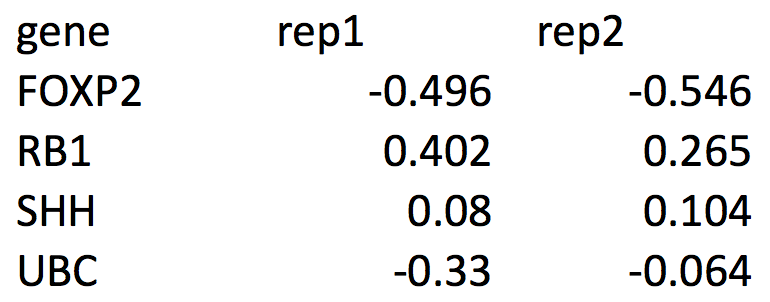

**2. UniProt accession numbers and logFC for two replicates**

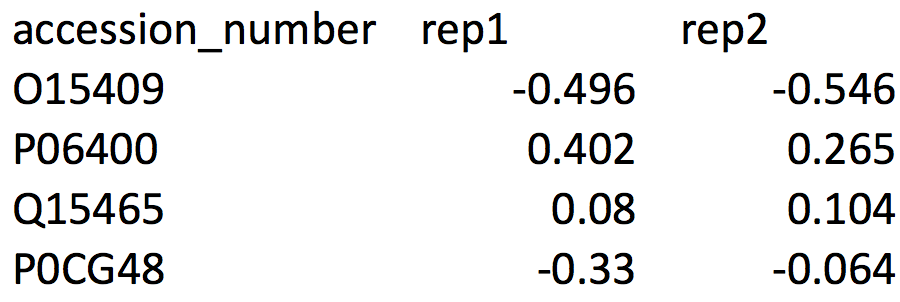

**3. HGNC symbol and results of statistical analyses**

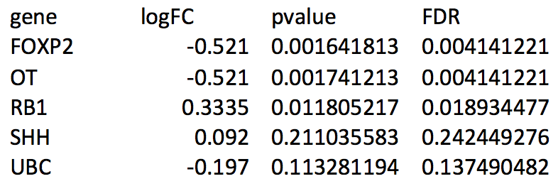

**4. UniProt accession numbers and results of statistical analyses**

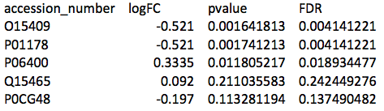

### What if my file is an Excel spreadhseet?

If your data is in Excel format and you are a Mac user, please convert to text file by selecting ‘File’ -> ‘Save As…’ and choose ‘Windows Formatted Text’ option as shown below.

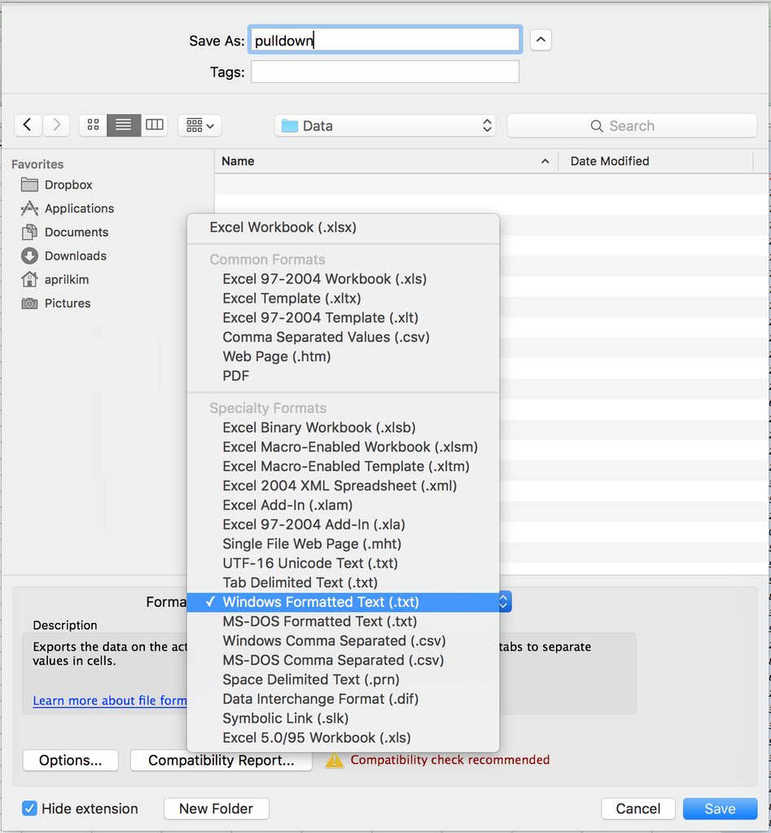

### What is the quality control (QC) workflow?

Upon upload, interactive volcano plot and scatter plot (if the user upload input includes rep1 and rep2 values) will be generated. Hovering over each marker will show the corresponding gene in HGNC symbol.

Genes of interest can be searched for on the interactive plots using the search function on the side panel.

The initial FDR threshold for color scale is 0.1. Results are shown as a volcano plot where logFC values of the bait versus control condition are plotted on the x-axis and the negative log10 transformed P values of that enrichment are plotted on the y-axis. Interaction partners that are enriched in the experiment with an FDR < 0.1 are green, and interaction partners with an FDR >= 0.1 are blue. Green proteins with a positive logFC are significantly enriched in bait condition and green proteins with a negative logFC are enriched in the control condition. Upon selection of new value, the interactive plots will render with the new color scale reflecting new FDR threshold value.

For convenience, markers can also be colored in grayscale or by ExAC pLI scores (details below).

Table on the right shows the count of interaction partners that are enriched in regions specified by the column headers and row titles.

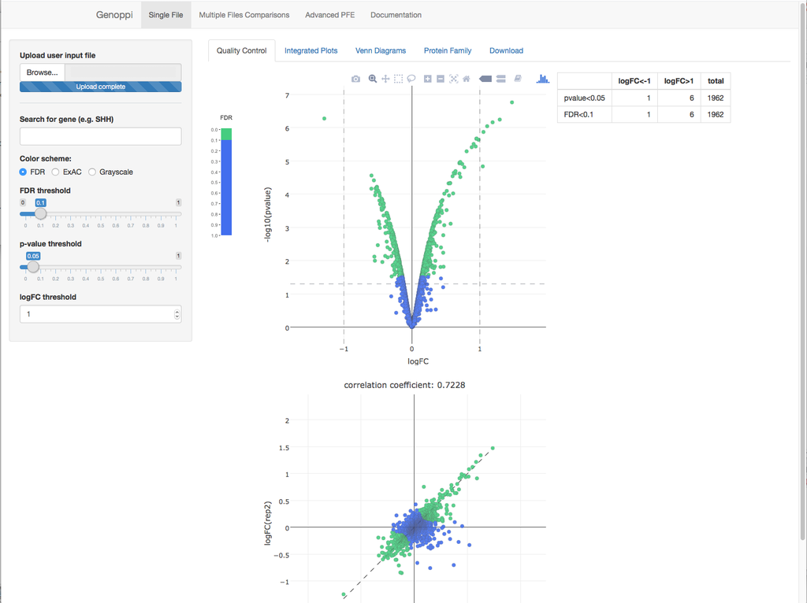

Further QC can be performed by identifying the known protein interaction partners from [InWeb](http://www.nature.com/nmeth/journal/v14/n1/abs/nmeth.4083.html) ([download InWeb](https://www.intomics.com/inbio/map/#downloads)).

InWeb contains known protein-protein interactions from >40,000 articles and overlaying this information and the experimental data serves as QC.

Known interaction partners of the bait protein, as determined by overlaying InWeb data, are highlighted in yellow enabling users to quality control the data and to distinguish known and new interaction partners.

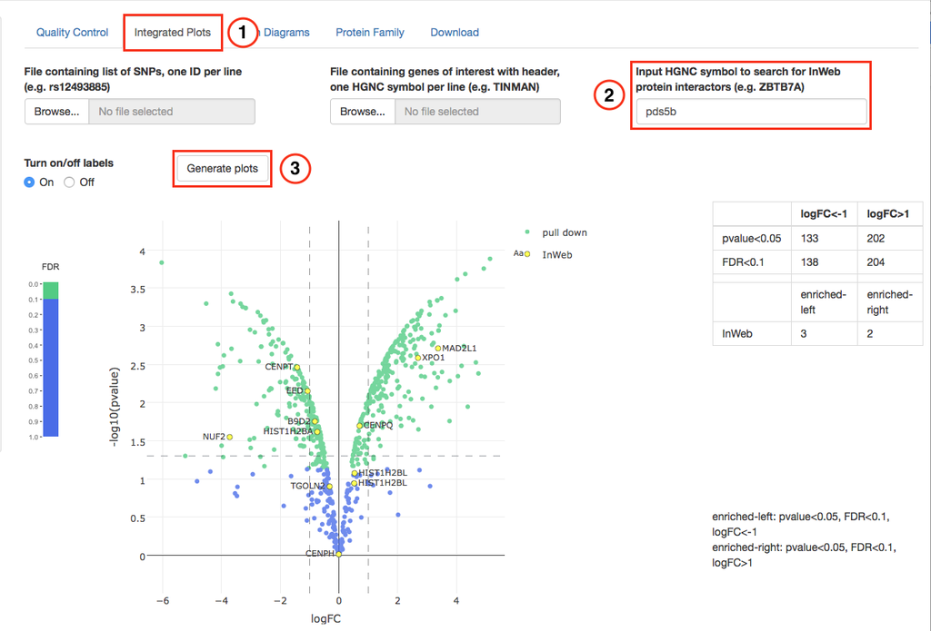

### How can I overlay genetics data?

Genoppi allows for visualization of experimental proteomics data with

- SNPs from genetic studies,
- user uploaded genes (e.g. set of interesting genes from [GTEx](http://www.gtexportal.org/home/)) to highlight corresponding proteins and
- protein encoded by genes that are intolerant to loss-of-function mutations as determined by [ExAC](http://exac.broadinstitute.org/) data

### SNP to gene mapping

Genoppi hosts pre-calculated pairwise measure of linkage disequilibrium (LD), which it uses to perform SNP-to-gene mapping using 1KG imputed single-nucleotide polymorphism (SNP) results.

The application will perform on-the-fly mapping of inputted SNPs to the 1KG genotypes and translate to a list of genes. For each CEU imputed SNP, genomic locus is defined as region containing r2>0.6 to the associated SNP within a 200-kb window; this region is then extended 50kb upstream and downstream. SNPs are mapped to candidate genes if the genomic coordinates of human protein-coding genes in hg19 overlap SNP loci.

If a SNP locus is a single-gene locus, the marker will be annotated as ‘SGL gene’ in the subsequent plot. If multiple protein-coding genes are present in SNP locus, all genes are mapped as candidate genes for the associated SNP and annotated as ‘MGL gene’ as shown below.

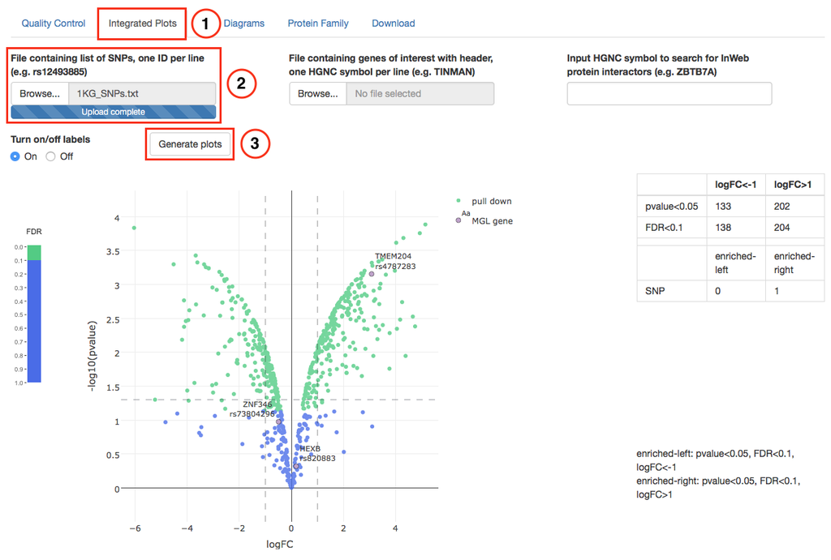

### Genes of interest

User must upload text file containing list(s) of corresponding protein’s genes in HGNC symbol for genes of interest mapping. First row of each column must contain the name describing the group of genes as shown below. There are no limits as to how many columns user may input.

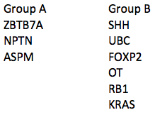

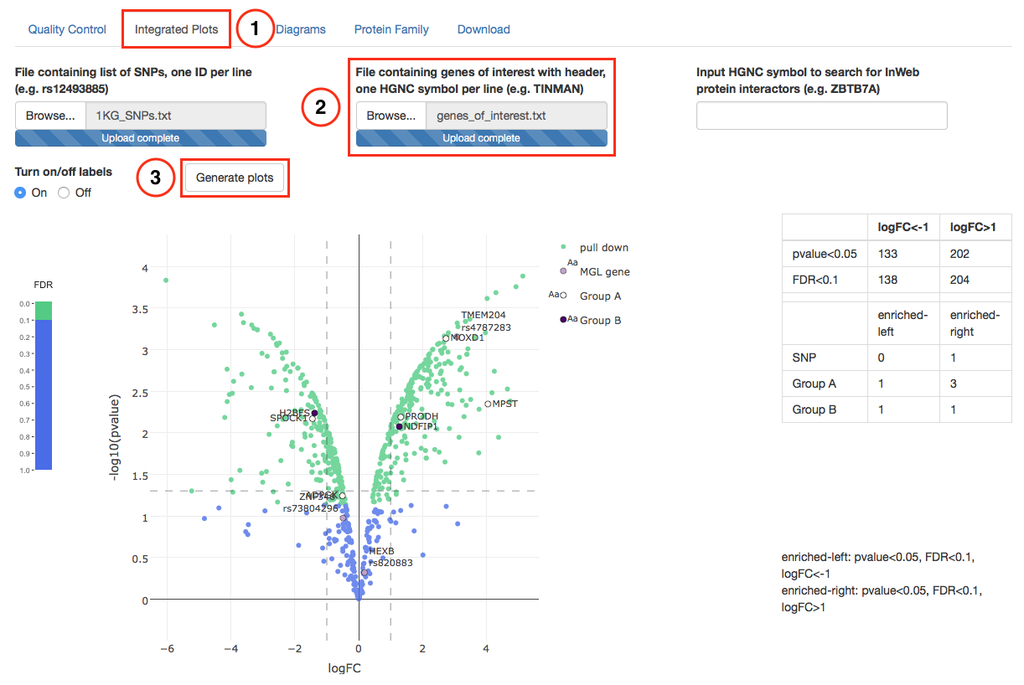

User may upload input files for both SNP to gene mapping and highlighting genes of interest as well as provide a HGNC symbol for searching interaction partners in InWeb. Any combination of fields may be filled and resulting plot will highlight all relevant proteins from user inputted data.

If, in the case, the plot becomes too “busy,” user can choose to turn the labels off or turn off the markers by clicking on the legend you wish to hide.

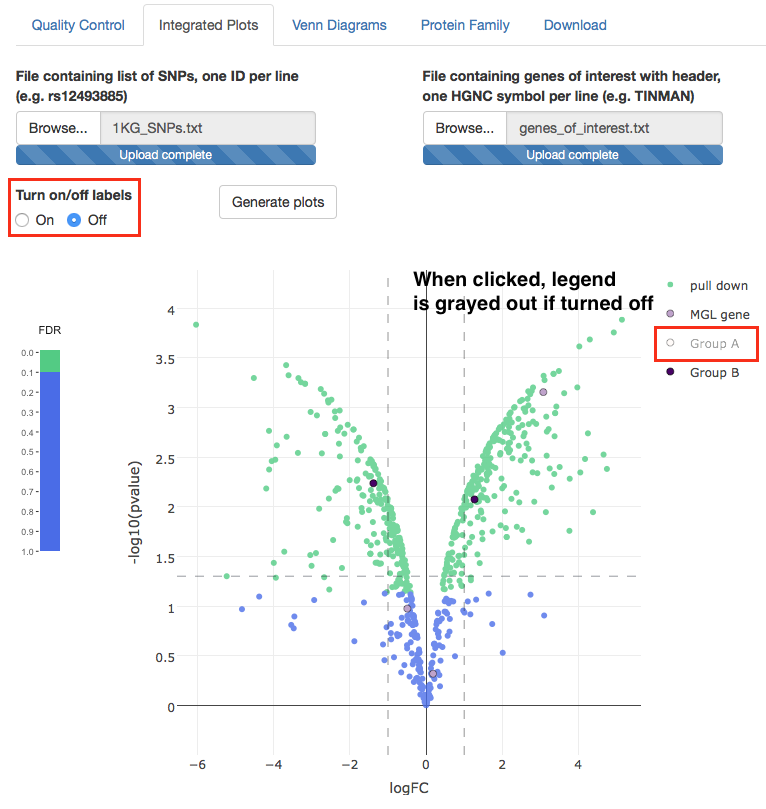

### Intolerance to LoF mutations determined by ExAC data

If at any point user would like to identify proteins encoded by genes likely to be extremely intolerant to loss-of-function variation using the ExAC data, user can choose the color scheme “ExAC” on the side panel.

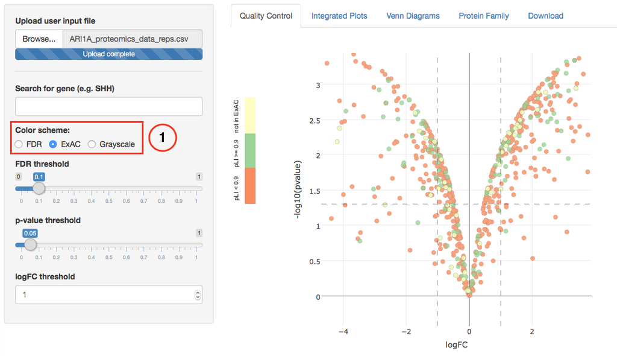

### V. How can I determine the significance of overlaps?

When different datasets are integrated with the proteomics data these overlaps are statistically tested and the results made available to users so they can determine, for example, the overlap of interaction partners of their protein of interest and genes genetically linked to a particular disease.

Hypergeometric distribution is used to calculate the significance of overlap between experimental proteomics data and known protein-protein interactions.

Using the InWeb interactors as an example, first, the overlap between experimental data and InWeb_IM database is found (population) followed by identification of its subset that passed user defined significance threshold (success in population). Second, for the chosen bait, list of literature known interacting proteins from the InWeb_IM database is identified and overlapped the pull down data (sample). Proteins that passed the user-defined significance threshold and found in InWeb_IM are then identified (success in sample). Hypergeometric test is run to calculate statistical significance of having given amount of successes in population, and the Venn diagram is generated to visualize the overlap of population and sample.

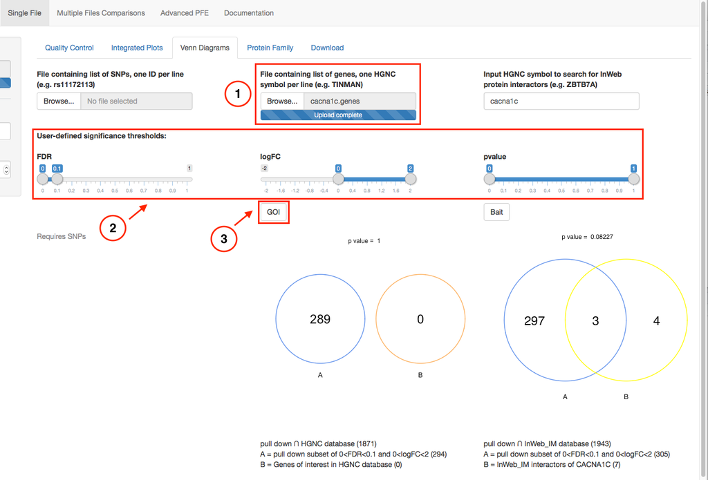

User can adjust the analysis thresholds during the analyses and have the changes (hypergeometric p value and counts) reflected immediately in the Venn diagrams.

### What protein families do the interactors belong to?

Experimental pull down data represented on a volcano plot can be overlaid with information on protein families of enriched genes based on user defined significance.

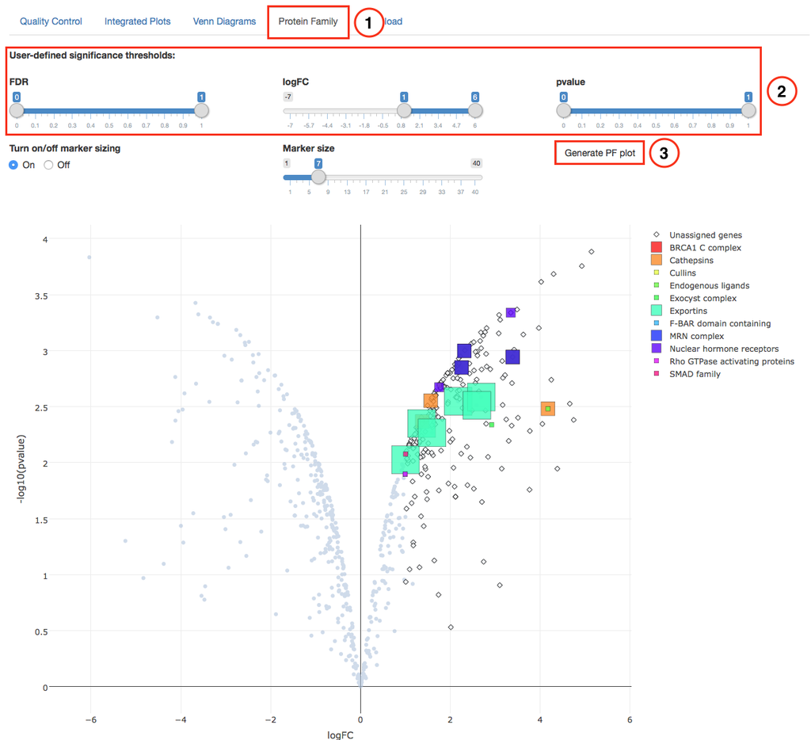

When marker sizing is turned on, the size of squares represent the number of respective protein families. Hovering over the marker will display protein encoded by gene in HGNC symbol, its protein family, and number of other proteins with the same protein family in user defined region.

Marker sizing can be turned off for equally sized markers. Any time user edits the input values, user must click on Generate Plot button to see the changes.

**1. Marker sizing on**

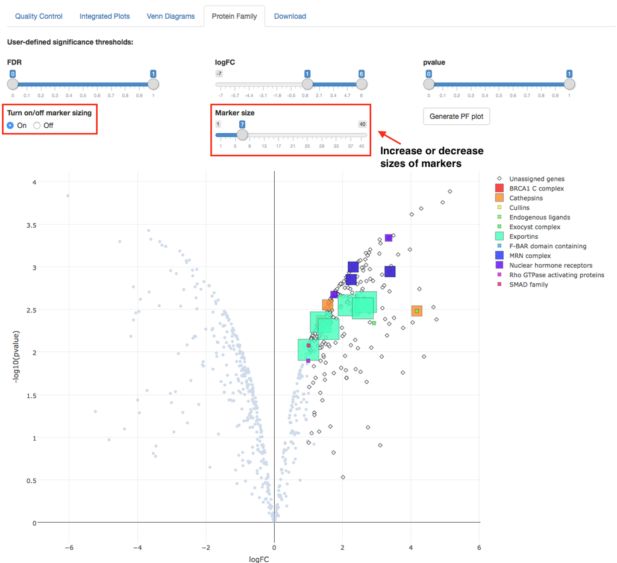

**2. Marker sizing off**

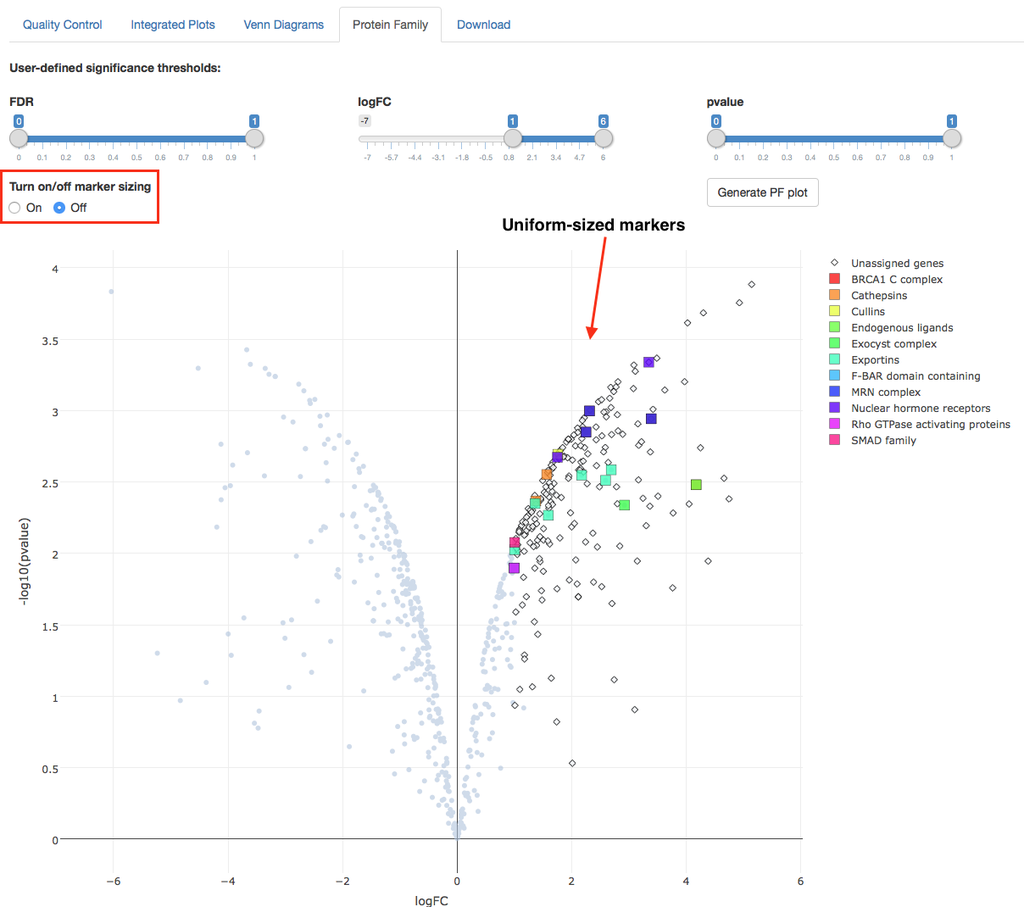

### How can I save my results?

User can download all generated data as text file and interactive plots as HTML reports.

Files and reports can only be downloaded if the relevant data and/or plots have been generated.

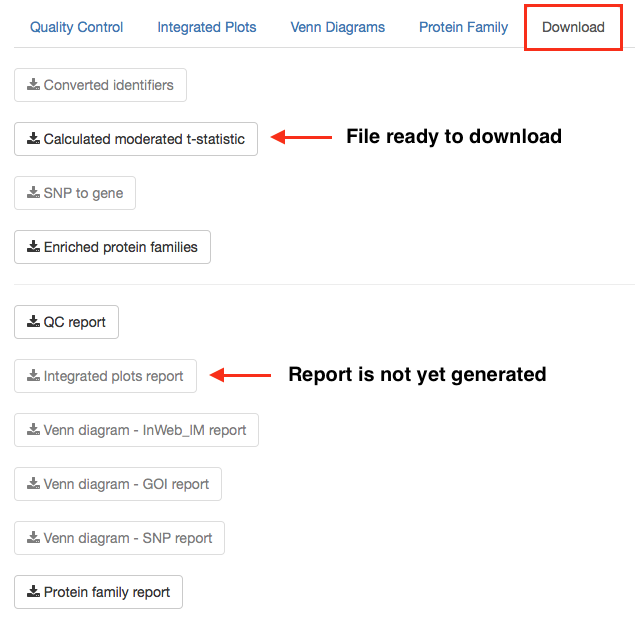

### Resources used

**Genoppi** doi: https://doi.org/10.1101/115576

**InWeb** Li,T. et al. (2016) A scored human protein-protein interaction network to catalyze genomic interpretation. Nat. Methods, 14, 64535.

**HGNC** Gray,K.A. et al. (2015) Genenames.org : the HGNC resources in 2015. Nucleic Acids Res., 43, 1079–1085.

**1KG imputed SNPs** The 1000 Genomes Project Consortium (2015) A global reference for human genetic variation. Nature, 526, 68–74.

**UniProt** The Uniprot Consortium (2015) UniProt : a hub for protein information. Nucleic Acids Res., 43, 204–212.